# Task 3: Asking the right questions and dplyr, R&CW redo

Rachael Smith

5/2/2020

## Part 1:

### Chapter 5 Notes

Tidyverse Conflicts x dplyr::filter() masks stats::filter() x dplyr::lag() masks stats::lag()

int = integer dbl = doubles, real numbers chr = character, vector, str dttm = date + time lgl = logicalcontain only TRUE FALSE fctr factors- fixed possible values date = dates

#### DATA MANIPULATION (dplyr)

filters() keep rows matching criteria arrange() reorder rows select() pick columns by name mutate() add new variables summarise() reduce variables to values group_by() operates group by group not entire dataset

Verbs * first argument is data fram *subsequent arguments describe what to do with the data- variable names NO QUOTES* result is a new data frame

SQL Joins: add new columns: *left join: all x + matching y* inner join: matching x + y don’t add new colums: *semi-join: all x with match in y* anit-join: all x W/O match in y

##### filter()

-only includes TRUE, does NOT include FALSE or NA

expression to filter data: filter(flights, month == 1, day == 1)

saves filter as new result jan1 <- filter(flights, month == 1, day == 1)

use () to print out and save results to variable (dec25 <- filter(flights, month ==12, day == 25))

###### Comparisons

== equality near() sqrt(2) ^ 2 == 2 #> [1] FALSE

```
near(sqrt(2) ^ 2,  2)
#> [1] TRUE
```

& and | or ! is not value %in% c(value, value)

###### Excercies

Had an arrival delay of two or more hours: #filter(flights, arr_delay >= 2)

Flew to Houston (IAH or HOU): #filter(flights, dest == “HOU” | dest == “IAH”)

Were operated by United, American, or Delta #filter(flights, carrier == “UA” | carrier == “AA” | carrier ==“DL”)

Departed in summer (July, August, and September) #filter(flights, between(month, 7, 9))

Arrived more than two hours late, but didn’t leave late #filter(flights, arr_delay > 120 & dep_delay <= 0)

Were delayed by at least an hour, but made up over 30 minutes in flight #filter(flights, dep_delay >= ‘60’ & arr_delay <= ‘-30’)

Departed between midnight and 6am (inclusive) #filter(flights, between(dep_time, 1, 600))

How many flights have a missing dep_time? What other variables are missing? What might these rows represent?  
# 8245 cancelled flights # filter(flights, is.na(dep_time))

Why is NA ^ 0 not missing? Why is NA | TRUE not missing? Why is FALSE & NA not missing? Can you figure out the general rule? (NA * 0 is a tricky counterexample!)

##### arrange()

similar to filter, changes order of rows desc() descending order

How could you use arrange() to sort all missing values to the start? (Hint: use is.na()).

Sort flights to find the most delayed flights. Find the flights that left earliest. #arrange(flights, desc(dep_delay))

Sort flights to find the fastest (highest speed) flights. #arrange(flights, distance/air_time)

Which flights travelled the farthest? Which travelled the shortest? #arrange(flights, distance) #arrange(flights, desc(distance))

#####select() pick variabls by names allows you to rapidly zoom in on useful subset using variable names

by name: variable, variable, variable

between inclusive: use colon except - *starts_with("“) *ends_with("")* contains(”“) *matches("(.)\1") repeated characters* num_range(”x", 1:3) matches x1, x2, x3* rename(flights, tail_num = tailnum)

#select(col1, col4, everythin())

#select(flights, contains(“TIME”))

##### mutate() create new variables with functions of existing variables

mutate adds new colums that are functions of existing.

flights_sml <- select(flights, year:day, ends_with(“delay”), distance, air_time ) mutate(flights_sml, gain = dep_delay - arr_delay, speed = distance / air_time * 60)

transmute- only keep new variables.

transmute(flights, gain = dep_delay - arr_delay, hours = air_time / 60, gain_per_hour = gain / hours

lead()= leading values lag() lagging values

log2() - easy to interpret cumsum() cumulitive sum cumprod() cummin() cummax() cummean() min_rank() row_number() dense_rank() percent_rank() cume_dist() ntile()

Currently dep_time and sched_dep_time are convenient to look at, but hard to compute with because they’re not really continuous numbers. Convert them to a more convenient representation of number of minutes since midnight. #transmute(flights, #+ dep_time, #+ hour = dep_time %/% 100, #+ minute = dep_time %% 100)

Compare air_time with arr_time - dep_time. What do you expect to see? What do you see? What do you need to do to fix it?

#transmute(flights, # gain = arr_time - dep_time, # air_time, # air_hours = air_time / 60, # gain_hours = gain / 60, # gain_per_hour = gain / hours)

Compare dep_time, sched_dep_time, and dep_delay. How would you expect those three numbers to be related?

#transmute(flights, # loss = (dep_time - sched_dep_time), # dep_delay)

Find the 10 most delayed flights using a ranking function. How do you want to handle ties? Carefully read the documentation for min_rank().

#head(min_rank(desc(flights$dep_delay)),10)

##### summarise() & group_by

*na.rm = TRUE* paired w/ group_by *Pipe Operator %>% “then” - make sure output is the same as the first input.

delays <- flights %>% group_by(dest) %>% summarise( count = n(), dist = mean(distance, na.rm = TRUE), delay = mean(arr_delay, na.rm = TRUE) ) %>% filter(count > 20, dest != “HNL”)

##### filter()

*A grouped filter is a grouped mutate followed by an ungrouped filter. I generally avoid them except for quick and dirty manipulations: otherwise it’s hard to check that you’ve done the manipulation correctly.*

### Data Science Questions

*Develop a few novel questions that data can answer*

[ ] Get feedback from 6-8 people on their interest in your questions and summarize this feedback

[ ] Find other examples of people addressing your question

[ ] Present your question to a data scientist/data analyst to get feedback on the quality of the question and if it can be addressed in 2-months.

[ ] Create one .rmd file that has your report

[ ] Have a section for each question

[ ] Be prepared to discuss your results in the upcoming class

#### Questions

##### Do we see more growth in students who attend the same school for a longer period of time?

I could not find any studies on this topic. I asked what do we know about students who attend the same school for consecutive years. This data might be helpful for the school that I am considering working with as we measure overall school growth and then growth of students who attend the school longer to see if there is a correlation.

##### Do we see a decline in student learning due to spring break or extended breaks?

I found a few articles that talked about student learning loss, specically summer learning loss.

https://www.malone.edu/files/resources/barberfinalthesis.pdf

https://www.brookings.edu/research/summer-learning-loss-what-is-it-and-what-can-we-do-about-it/

##### How do we measure non-academic growth in students?

https://www.panoramaed.com/social-emotional-learning-sel

I found a tool that measures growth in self-management, social awareness, growth mindset, and self-efficacy.

## Part 2: Research and Creative Works Vizualization

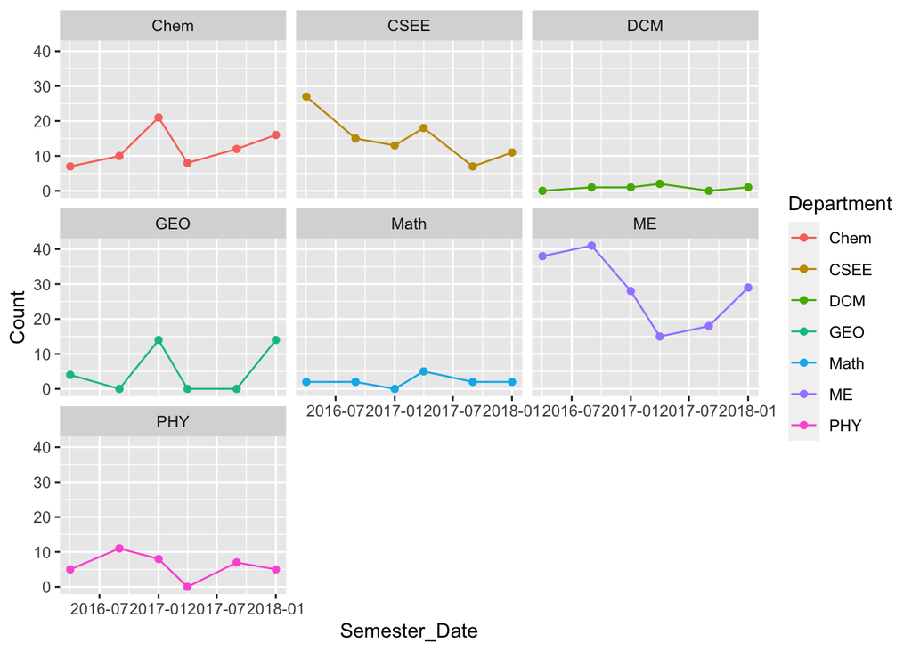

```r
RCW <- dat %>%
  group_by(Semester_Date, Department) %>%
  select(Count, Department, Year, Semester_Date)

ggplot(dat = RCW) +
  aes(x = Semester_Date, y = Count, colour = Department) +
  geom_point() +
  geom_line(aes(group = Department))+
  facet_wrap(~Department)
```

```r
ggsave(
  filename = "Department Growth by Semester.png",
  plot = last_plot(),
  width = 10,
  dpi = 300)
```